# 3주차 패키지

# 0번

```r
setwd("C:/Users/Yunhee/Desktop/P-SAT/2020-2/패키지/클린업/3주차패키지")

train <- fread("train2.csv",
               header = T,
               stringsAsFactors = F,
               data.table = F,
               encoding = "UTF-8",
               drop = c("HOM_CCG_NM", "CARD_CCG_NM", "AGE"))


train = train %>% mutate_at(vars(YEAR, SEX_CTGO_CD, FLC), as.character)

test <- fread("test2.csv",
              header = T,
              stringsAsFactors = F,
              data.table = F,
              encoding = "UTF-8",
              drop = c("HOM_CCG_NM", "CARD_CCG_NM", "AGE"))

test = test %>% mutate_at(vars(YEAR, SEX_CTGO_CD, FLC), as.character)
```

```r
## 범주 수 ##
apply(select_if(train, is.character), 2, n_distinct)
```

```
## STD_CLSS_NM SEX_CTGO_CD         FLC        YEAR
##          12           2           5           2
```

```r
## NA 수 ##
is.na(train) %>% colSums()
```

```
## STD_CLSS_NM       AGE_N SEX_CTGO_CD         FLC   CSTMR_CNT         AMT
##           0           0           0           0           0           0
##         CNT        YEAR
##           0           0
```

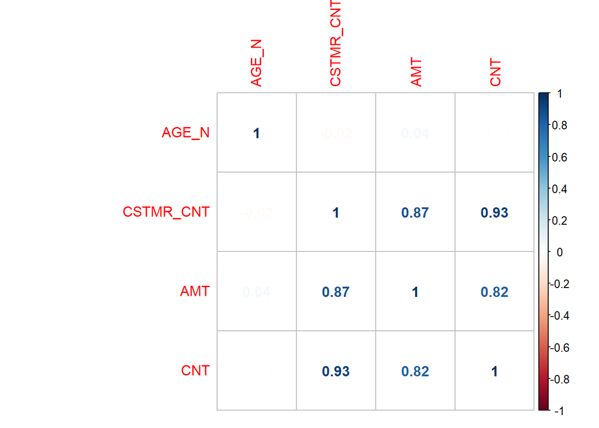

```r
## correlation
corrplot(cor(select_if(train, is.numeric)), method = "number")
```

```r
## train에는 없지만 test에는 있는 범주 / test에는 없지만 train에는 있는 범주
new_factor <- data.frame(variable = colnames(select_if(train, is.character)),
                         value = NA,
                         value2 = NA)
for(i in 1 : nrow(new_factor)){
  new_factor[i, "value"] =
    sum(!unique(test[,new_factor[i, "variable"]]) %in% unique(train[,new_factor[i, "variable"]]))
  new_factor[i, "value2"] =
    sum(!unique(train[,new_factor[i, "variable"]]) %in% unique(test[,new_factor[i, "variable"]]))
}

new_factor
```

[output not shown]

```r
test$SEX_CTGO_CD %>% unique
```

```
## [1] "1" "2"
```

```r
train$SEX_CTGO_CD %>% unique
```

```
## [1] "1" "2"
```

```r
train$YEAR %>% unique()
```

```
## [1] "2019" "2020"
```

```r
test$YEAR %>% unique() ## test에는 2019년이 없음
```

```
## [1] "2020"
```

```r
rm(list = ls()[which(!ls() %in% c("train", "test"))])
```

# 1-1

## 1-1-1

```r
tune_rf <- expand.grid(mtry = 2:6, ntree = c(100, 200, 300))
tune_rf$RMSE <- NA
tune_rf
```

```
##    mtry ntree RMSE
## 1     2   100   NA
## 2     3   100   NA
## 3     4   100   NA
## 4     5   100   NA
## 5     6   100   NA
## 6     2   200   NA
## 7     3   200   NA
## 8     4   200   NA
## 9     5   200   NA
## 10    6   200   NA
## 11    2   300   NA
## 12    3   300   NA
## 13    4   300   NA
## 14    5   300   NA
## 15    6   300   NA
```

```r
set.seed(1234)
cv <- createFolds(train$AMT, k = 5)

train = train %>% mutate_if(is.character, as.factor)
```

```r
pb <- progress_bar$new(total = 75) ##15(nrow(tune_rf))*5(fold)

for(i in 1:nrow(tune_rf)){
  print(paste0('mtry ', tune_rf[i,'mtry']))
  print(paste0('ntree ', tune_rf[i,'ntree']))
  fold_RMSE = NULL
  for(k in 1:5){
    print(paste0(k, ' -FOLD'))
    index = cv[[k]]
    train_rf = train[ -index, ]
    vali_rf = train[index, ]
    vali_AMT = vali_rf$AMT

    set.seed(1234)
    rf_mod_1 <- randomForest(AMT~., train_rf, mtry = tune_rf[i,'mtry'], ntree = tune_rf[i, 'ntree'])
    rf_pred_1 <- predict(rf_mod_1, newdata = select(vali_rf, -AMT))
    RMSE <- RMSE(rf_pred_1, vali_AMT)
    fold_RMSE = c(fold_RMSE, RMSE)

    pb$tick()
    Sys.sleep(0.01)
  }
  mean_RMSE = mean(fold_RMSE)
  tune_rf[i,'RMSE'] <- mean_RMSE
}
```

```
## [1] "mtry 2"
## [1] "ntree 100"
## [1] "1 -FOLD"
## [1] "2 -FOLD"
## [1] "3 -FOLD"
## [1] "4 -FOLD"
## [1] "5 -FOLD"
## [1] "mtry 3"
## [1] "ntree 100"
## [1] "1 -FOLD"
## [1] "2 -FOLD"
## [1] "3 -FOLD"
## [1] "4 -FOLD"
## [1] "5 -FOLD"
## [1] "mtry 4"
```

[output cut: 90 more lines]

## 1-1-2

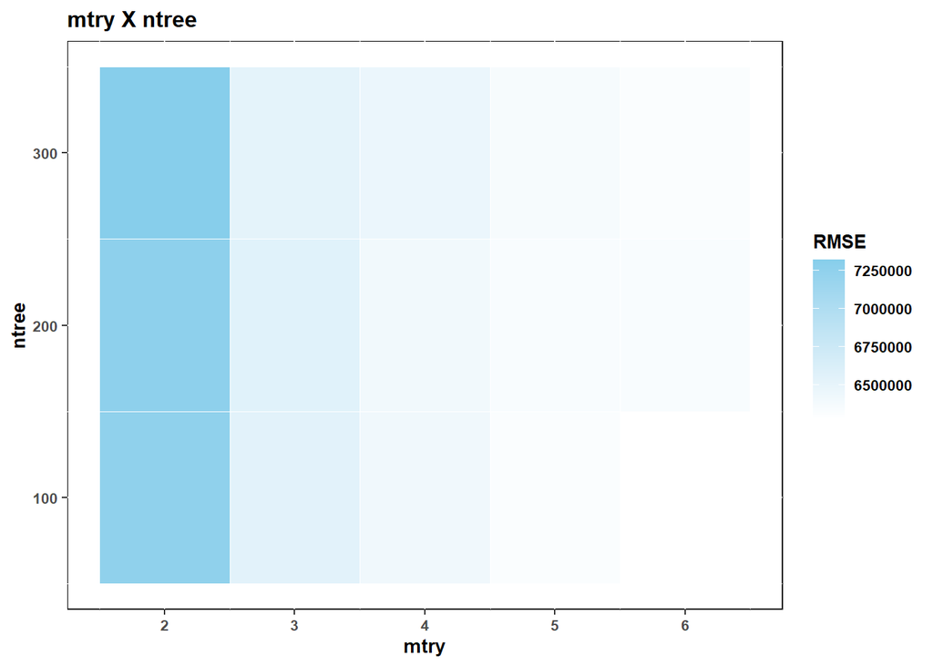

```r
ggplot(tune_rf) +
  geom_tile(aes(mtry, ntree, fill = RMSE), color = 'white') +
  labs(x = "mtry", y = "ntree", title = "mtry X ntree") +
  scale_fill_gradient("RMSE", low = "white", high = "skyblue") +
  theme(panel.background = element_rect(fill = "white" , color = "black"),
        text = element_text(face = "bold", size = 10))
```

## 1-1-3

```r
tune_rf[which(tune_rf$RMSE == min(tune_rf$RMSE)), ]
```

```
##   mtry ntree    RMSE
## 5    6   100 6278217
```

#### mtry, 즉 노드마다 선택될 변수의 개수는 6개, 생성될 나무의 개수 ntree는 100일 때 rmse가 가장 낮았다. 일반적으로 회귀 모델에서는 총 변수 개수의 제곱근으로 mtry를 선택한다. 하지만 여기서는 선택 변수 개수가 많은 것이 rmse가 낮게 나왔다. ntree가 300이 아니라 100일 때 rmse가 가장 낮은 것은 나무 개수가 많아지면 train에 대해 과적합이 일어나기 때문이라고 볼 수 있다.

```r
rm(rf_mod_1, rf_pred_1)
```

# 1-2

## 1-2-1

```r
tune_rng <- expand.grid(mtry = 2:6, ntree = c(100, 200, 300))
tune_rng$RMSE <- NA
tune_rng
```

```
##    mtry ntree RMSE
## 1     2   100   NA
## 2     3   100   NA
## 3     4   100   NA
## 4     5   100   NA
## 5     6   100   NA
## 6     2   200   NA
## 7     3   200   NA
## 8     4   200   NA
## 9     5   200   NA
## 10    6   200   NA
## 11    2   300   NA
## 12    3   300   NA
## 13    4   300   NA
## 14    5   300   NA
## 15    6   300   NA
```

```r
pb <- progress_bar$new(total = 75)

for(i in 1:nrow(tune_rng)){
  print(paste0('mtry ', tune_rng[i,'mtry']))
  print(paste0('ntree ', tune_rng[i,'ntree']))
  fold_RMSE = NULL
  for(k in 1:5){
    print(paste0(k, ' -FOLD'))
    index = cv[[k]]
    train_rng = train[ -index, ]
    vali_rng = train[index, ]
    vali_AMT = vali_rng$AMT

    rng_mod_1 <- ranger(AMT~., train_rng, mtry = tune_rng[i,'mtry'], num.trees = tune_rng[i, 'ntree'], seed = 1234)
    rng_pred_1 <- predict(rng_mod_1, data = select(vali_rng, -AMT), seed = 1234)
    RMSE <- RMSE(rng_pred_1$predictions, vali_AMT)
    fold_RMSE = c(fold_RMSE, RMSE)

    pb$tick()
    Sys.sleep(0.01)
  }
  mean_RMSE = mean(fold_RMSE)
  tune_rng[i,'RMSE'] <- mean_RMSE
}
```

```
## [1] "mtry 2"
## [1] "ntree 100"
## [1] "1 -FOLD"
## [1] "2 -FOLD"
## [1] "3 -FOLD"
## [1] "4 -FOLD"
## [1] "5 -FOLD"
## [1] "mtry 3"
## [1] "ntree 100"
## [1] "1 -FOLD"
## [1] "2 -FOLD"
## [1] "3 -FOLD"
## [1] "4 -FOLD"
## [1] "5 -FOLD"
## [1] "mtry 4"
```

[output cut: 90 more lines]

## 1-2-2

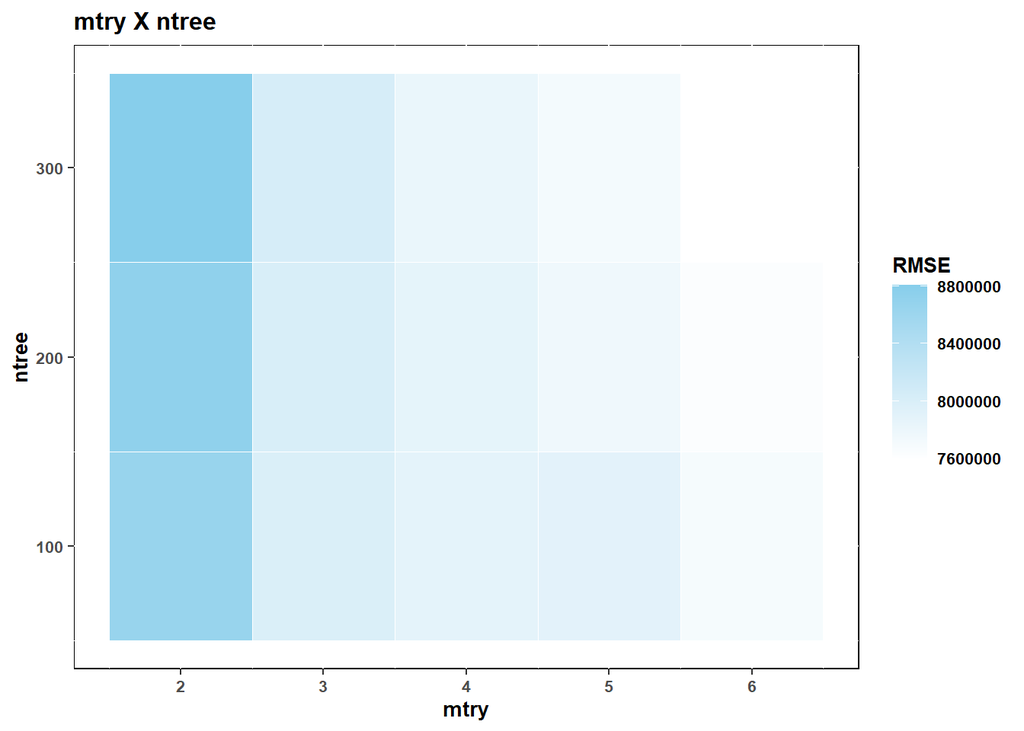

```r
ggplot(tune_rng) +
  geom_tile(aes(mtry, ntree, fill = RMSE), color = 'white') +
  labs(x = "mtry", y = "ntree", title = "mtry X ntree") +
  scale_fill_gradient("RMSE", low = "white", high = "skyblue") +
  theme(panel.background = element_rect(fill = "white" , color = "black"),
        text = element_text(face = "bold", size = 10))
```

## 1-2-3

```r
tune_rng[which(tune_rng$RMSE == min(tune_rng$RMSE)), ]
```

```
##    mtry ntree    RMSE
## 15    6   300 7589369
```

```r
rm(rng_mod_1, rng_pred_1)
```

# 1-3

```r
fac_row = train[train$YEAR == 2019, ] %>% rownames ##test에는 2019가 없으므로 train$YEAR == 2019인 임의의 row를 하나 뽑는다

set.seed(1234)
test_rf = rbind(test, train[sample(fac_row, 1), ]) %>% mutate_if(is.character, as.factor) ##test와 rbind
```

```r
library(tictoc)

tic() ; start = Sys.time()
set.seed(1234)
rf_mod_2 <- randomForest(AMT~., train, mtry = 6, ntree = 100)
toc() ; end = Sys.time() ; rf_time = end - start
```

```
## 42.14 sec elapsed
```

```r
rf_pred_2 <- predict(rf_mod_2, select(test_rf, -AMT))

RMSE_rf = RMSE(rf_pred_2, test_rf$AMT)



tic() ; start = Sys.time()
rng_mod_2 <- ranger(AMT~., train, mtry = 6, num.trees = 300, seed = 1234)
toc() ; end = Sys.time() ; rng_time = end - start
```

```
## 1.18 sec elapsed
```

```r
rng_pred_2 <- predict(rng_mod_2, select(test_rf, -AMT), seed = 1234) ##ranger는 그냥도 돌아가긴 하는데 랜포랑 비교하려고 같은 test set 썼어요

RMSE_rng = RMSE(rng_pred_2$predictions, test_rf$AMT)
```

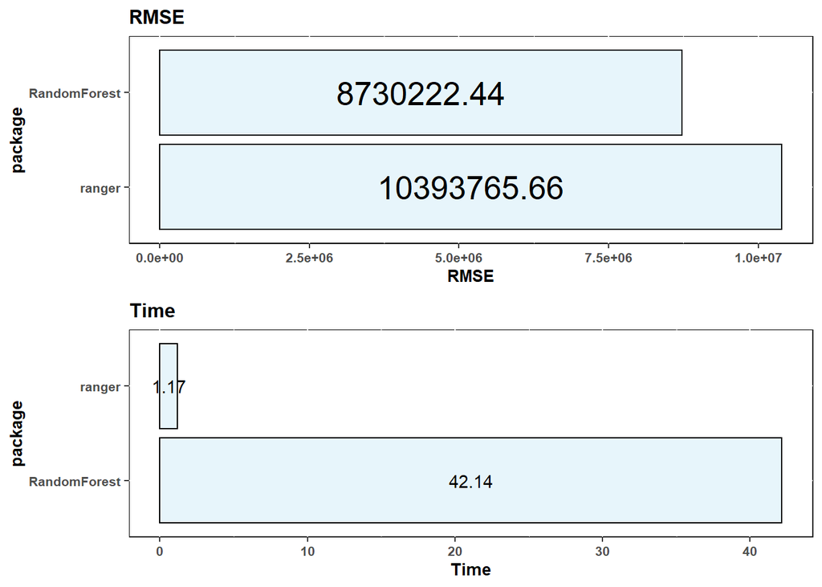

```r
pack = data.frame(package = c('RandomForest', 'ranger'), RMSE = c(RMSE_rf, RMSE_rng) %>% round(2),
                  Time = c(rf_time, rng_time) %>% as.numeric %>% round(2))


p1 = ggplot(pack, aes(x = reorder(package, -RMSE), y = RMSE)) +
  geom_col(alpha = 0.2, fill = 'skyblue', color='black') +
  coord_flip()+
  labs(x = "package", y = "RMSE", title = "RMSE") +
  geom_text(aes(label = RMSE), position = position_stack(0.5), size = 7) +
  theme(panel.background = element_rect(fill = "white", color = "black"),
        text = element_text(face = "bold", size = 10))


p2 = ggplot(pack, aes(x = reorder(package, -Time), y = Time)) +
  geom_col(alpha = 0.2, fill = 'skyblue', color='black') +
  coord_flip()+
  labs(x = "package", y = "Time", title = "Time") +
  geom_text(aes(label = Time), position = position_stack(0.5)) +
  theme(panel.background = element_rect(fill = "white", color = "black"),
        text = element_text(face = "bold", size = 10))

grid.arrange(p1, p2, nrow = 2)
```

#### ranger가 훨씬 빠르지만 rmse는 랜덤포레스트가 더 좋게 나왔다. 모델의 성능을 고려하면 랜포가 더 뛰어나지만 고차원 데이터일 경우에는 시간 문제로 인해 ranger가 더 효율적이라고 볼 수 있을 것이다.

```r
rm(list = ls()[which(!ls() %in% c("train", "test", 'test_rf'))])
```

# 2-0

## 2-0-1

```r
train_d = dummy.data.frame(train)
test_d = dummy.data.frame(test_rf)
```

#### xg도 랜덤포레스트와 같이 train과 test의 범주 레벨이 달라지는 문제가 있어 아까 year의 level을 맞춰 놓은 test set을 더미화한다.

## 2-0-2

```r
xgb_tr = xgb.DMatrix(as.matrix(train_d %>% select(-AMT)), label = train_d$AMT)
xgb_te = xgb.DMatrix(as.matrix(test_d %>% select(-AMT)), label = test_d$AMT)
```

# 2-1

## 2-1-1

```r
max_depth = NULL
min_child_weight = NULL
subsample = NULL
colsample_bytree = NULL
eta = NULL
nrounds = NULL

set.seed(1234)
for (i in 1:10){
  max_depth = c(max_depth, sample(3:8, 1))
  min_child_weight = c(min_child_weight, sample(3:8, 1))
  subsample = c(subsample, runif(1, 0.6, 1))
  colsample_bytree = c(colsample_bytree, runif(1, 0.6, 1))
  eta = c(eta, runif(1, 0.01, 0.3))
  nrounds = c(nrounds, sample(c(500, 600, 700, 800), 1))
}

tune_xgb = data.frame(max_depth = max_depth,
                           min_child_weight = min_child_weight,
                           subsample = subsample,
                           colsample_bytree = colsample_bytree,
                           eta = eta,
                           nrounds = nrounds,
                           RMSE = NA
                           )
tune_xgb
```

```
##    max_depth min_child_weight subsample colsample_bytree        eta nrounds
## 1          6                4 0.8493518        0.9443662 0.19569008     700
## 2          3                7 0.8057005        0.8774365 0.16804270     600
## 3          8                4 0.7144893        0.7067283 0.06414961     800
## 4          8                8 0.6636184        0.6159984 0.07345187     800
## 5          7                6 0.6183081        0.7824366 0.08690413     700
## 6          7                4 0.6804992        0.7035239 0.29772362     700
## 7          5                6 0.8487277        0.7319081 0.15557927     700
## 8          3                5 0.9061839        0.6295120 0.09980911     800
## 9          4                5 0.8015734        0.7975844 0.22784806     600
## 10         3                8 0.6167429        0.7268729 0.01398748     500
##    RMSE
## 1    NA
## 2    NA
## 3    NA
## 4    NA
## 5    NA
## 6    NA
## 7    NA
## 8    NA
## 9    NA
## 10   NA
```

```r
rm(colsample_bytree, eta, i ,max_depth, min_child_weight, nrounds, subsample)
```

```r
set.seed(1234)
cv_xgb = createFolds(train_d$AMT, k = 5)

pb <- progress_bar$new(total = 50)



for (i in 1:10){
  print(paste0('Tune ', i))
  params = list(objective = 'reg:linear',
                max_depth = tune_xgb$max_depth[i],
                min_child_weight = tune_xgb$min_child_weight[i],
                subsample = tune_xgb$subsample[i],
                colsample_bytree = tune_xgb$colsample_bytree[i],
                eta = tune_xgb$eta[i]
                )
  fold_RMSE = NULL

  for (k in 1:5){
    print(paste0(k, ' -FOLD'))
    index <- cv_xgb[[k]]
    train_x<- train_d[-index,]
    val_x <- train_d[index,]
    train_xgb = xgb.DMatrix(as.matrix(train_x %>% select(-AMT)), label = train_x$AMT)
    vali_xgb = xgb.DMatrix(as.matrix(val_x %>% select(-AMT)), label = val_x$AMT)
    watchlist = list(train = train_xgb, test = vali_xgb)

    set.seed(1234)
    xgb_mod_1 = xgb.train(params = params,
                        data = train_xgb,
                        watchlist = watchlist, nrounds = tune_xgb$nrounds[i],
                        verbose = 0,
                        early_stopping_rounds = 0.05*tune_xgb$nrounds[i]
                        )
    xgb_pred_1 <- predict(xgb_mod_1, newdata = vali_xgb)
    RMSE <- RMSE(xgb_pred_1,val_x$AMT)
    fold_RMSE = c(fold_RMSE, RMSE)

    pb$tick()
    Sys.sleep(0.01)
  }
  mean_RMSE = mean(fold_RMSE)
  tune_xgb[i,'RMSE'] <- mean_RMSE
}
```

```
## [1] "Tune 1"
## [1] "1 -FOLD"
## [1] "2 -FOLD"
## [1] "3 -FOLD"
## [1] "4 -FOLD"
## [1] "5 -FOLD"
## [1] "Tune 2"
## [1] "1 -FOLD"
## [1] "2 -FOLD"
## [1] "3 -FOLD"
## [1] "4 -FOLD"
## [1] "5 -FOLD"
## [1] "Tune 3"
## [1] "1 -FOLD"
## [1] "2 -FOLD"
```

[output cut: 45 more lines]

## 2-1-2

```r
tune_xgb[which(tune_xgb$RMSE==min(tune_xgb$RMSE)), ]
```

```
##   max_depth min_child_weight subsample colsample_bytree       eta nrounds
## 9         4                5 0.8015734        0.7975844 0.2278481     600
##      RMSE
## 9 6368419
```

## 2-1-3

#### xgboost처럼 하이퍼 파라미터가 다양한 경우에는 그리드 서치만으로 최적화된 파라미터를 찾기에는 한계가 있다. 그리드 서치는 사용자가 임의로 파라미터의 튜닝할 범위와 조합을 고려해야 하므로 파라미터의 개수가 늘어나면 튜닝 시간이 굉장히 길어지게 된다. 하지만 랜덤 튜닝은 각 파라미터 범위 내에서 랜덤 샘플링으로 파라미터 조합을 바로 생성한다. 즉 그리드 사이의 값들도 확률적으로 고려하면서 불필요한 탐색 횟수를 줄이게 되므로 빠르게 최적화가 가능하다는 의미이다.(경제적이다) 또한 그리드 서치는 사용자가 서치를 중단했을 경우 파라미터의 일부 범위가 통째로 제외되는데, 랜덤 튜닝은 중간에 그만두더라도 덜 부담된다.

```r
rm(xgb_mod_1, xgb_pred_1)
```

# 2-2

## 2-2-1

```r
depth_weight_grid = expand.grid(max_depth = 2:6, min_child_weight = 3:7, RMSE = NA)
depth_weight_grid
```

```
##    max_depth min_child_weight RMSE
## 1          2                3   NA
## 2          3                3   NA
## 3          4                3   NA
## 4          5                3   NA
## 5          6                3   NA
## 6          2                4   NA
## 7          3                4   NA
## 8          4                4   NA
## 9          5                4   NA
## 10         6                4   NA
## 11         2                5   NA
## 12         3                5   NA
## 13         4                5   NA
## 14         5                5   NA
## 15         6                5   NA
## 16         2                6   NA
## 17         3                6   NA
## 18         4                6   NA
## 19         5                6   NA
## 20         6                6   NA
## 21         2                7   NA
## 22         3                7   NA
## 23         4                7   NA
## 24         5                7   NA
## 25         6                7   NA
```

```r
pb <- progress_bar$new(total = 125)
for (i in 1:25){
  print(paste0('max_depth ', depth_weight_grid[i,'max_depth']))
  print(paste0('min_child_weight ', depth_weight_grid[i,'min_child_weight']))
  params = list(objective = 'reg:linear',
                max_depth = depth_weight_grid$max_depth[i],
                min_child_weight = depth_weight_grid$min_child_weight[i],
                subsample = tune_xgb$subsample[9],
                colsample_bytree = tune_xgb$colsample_bytree[9],
                eta = tune_xgb$eta[9]
  )
  fold_RMSE = NULL
  for (k in 1:5){
    print(paste0(k, ' -FOLD'))
    index <- cv_xgb[[k]]
    train_x<- train_d[-index,]
    val_x <- train_d[index,]
    train_xgb = xgb.DMatrix(as.matrix(train_x %>% select(-AMT)), label = train_x$AMT)
    vali_xgb = xgb.DMatrix(as.matrix(val_x %>% select(-AMT)), label = val_x$AMT)
    watchlist = list(train = train_xgb, test = vali_xgb)

    set.seed(1234)
    xgb_mod_2 = xgb.train(params = params,
                        data = train_xgb,
                        watchlist = watchlist, nrounds = tune_xgb$nrounds[9],
                        verbose = 0,
                        early_stopping_rounds = 0.05*tune_xgb$nrounds[9]
    )
    xgb_pred_2 <- predict(xgb_mod_2, newdata = vali_xgb)
    RMSE <- RMSE(xgb_pred_2,val_x$AMT)
    fold_RMSE = c(fold_RMSE, RMSE)

    pb$tick()
    Sys.sleep(0.01)
  }
  mean_RMSE = mean(fold_RMSE)
  depth_weight_grid[i,'RMSE'] <- mean_RMSE
}
```

```
## [1] "max_depth 2"
## [1] "min_child_weight 3"
## [1] "1 -FOLD"
## [1] "2 -FOLD"
## [1] "3 -FOLD"
## [1] "4 -FOLD"
## [1] "5 -FOLD"
## [1] "max_depth 3"
## [1] "min_child_weight 3"
## [1] "1 -FOLD"
## [1] "2 -FOLD"
## [1] "3 -FOLD"
## [1] "4 -FOLD"
## [1] "5 -FOLD"
## [1] "max_depth 4"
```

[output cut: 160 more lines]

## 2-2-2

```r
depth_weight_grid[which(depth_weight_grid$RMSE==min(depth_weight_grid$RMSE)), ]
```

```
##   max_depth min_child_weight    RMSE
## 5         6                3 6212437
```

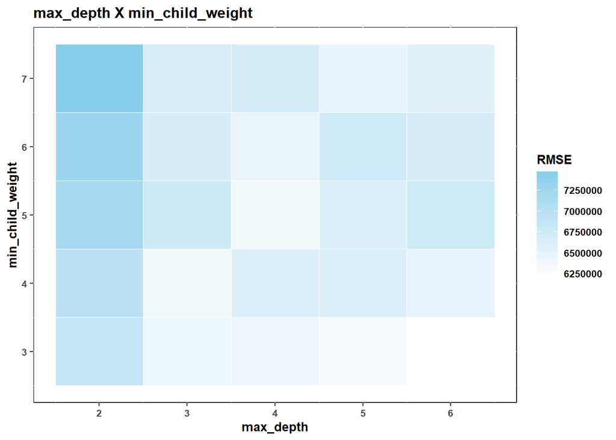

```r
ggplot(depth_weight_grid) +
  geom_tile(aes(max_depth, min_child_weight, fill = RMSE), color = 'white') +
  labs(x = "max_depth", y = "min_child_weight", title = "max_depth X min_child_weight") +
  scale_fill_gradient("RMSE", low = "white", high = "skyblue") +
  theme(panel.background = element_rect(fill = "white" , color = "black"),
        text = element_text(face = "bold", size = 10))
```

#### max_depth와 min_child_weight를 grid search하는 이유는 트리의 최대 깊이가 커질수록 bias는 낮아지고 variance는 커지는 반면 노드 최소 가중치 합이 커질수록 bias는 커지고 variance는 작아지기 때문인 듯 싶다. 둘 다 bias와 variance에 영향을 주니까.. #### 최대 깊이는 기본값인 6, 가중치의 최소 합은 3애서 rmse가 가장 낮게 나왔다. 플롯을 보면 깊이는 깊어질수록 rmse가 줄어드는 것이 보이고, 가중치 최소 합은 작을수록 더 많은 split이 가능하므로 rmse가 작아진다고 볼 수 있을 것이다.

```r
rm(xgb_mod_2, xgb_pred_2)
```

## 2-2-3

```r
sub_col_grid = expand.grid(subsample = seq(tune_xgb$subsample[9] - 0.1, tune_xgb$subsample[9] + 0.1, 0.04),
                           colsample_bytree = seq(tune_xgb$colsample_bytree[9] - 0.1, tune_xgb$colsample_bytree[9] + 0.1, 0.04), RMSE = NA)

pb <- progress_bar$new(total = 180)
for (i in 1:36){
  print(paste0('subsample ', sub_col_grid[i,'subsample']))
  print(paste0('colsample_bytree ', sub_col_grid[i,'colsample_bytree']))
  params = list(objective = 'reg:linear',
                max_depth = 6,
                min_child_weight = 3,
                subsample = sub_col_grid$subsample[i],
                colsample_bytree = sub_col_grid$colsample_bytree[i],
                eta = tune_xgb$eta[9]
  )
  fold_RMSE = NULL
  for (k in 1:5){
    print(paste0(k, ' -FOLD'))
    index <- cv_xgb[[k]]
    train_x<- train_d[-index,]
    val_x <- train_d[index,]
    train_xgb = xgb.DMatrix(as.matrix(train_x %>% select(-AMT)), label = train_x$AMT)
    vali_xgb = xgb.DMatrix(as.matrix(val_x %>% select(-AMT)), label = val_x$AMT)
    watchlist = list(train = train_xgb, test = vali_xgb)

    set.seed(1234)
    xgb_mod_3 = xgb.train(params = params,
                        data = train_xgb,
                        watchlist = watchlist, nrounds = tune_xgb$nrounds[9],
                        verbose = 0,
                        early_stopping_rounds = 0.05*tune_xgb$nrounds[9]
    )
    xgb_pred_3 <- predict(xgb_mod_3, newdata = vali_xgb)
    RMSE <- RMSE(xgb_pred_3,val_x$AMT)
    fold_RMSE = c(fold_RMSE, RMSE)

    pb$tick()
    Sys.sleep(0.01)
  }
  mean_RMSE = mean(fold_RMSE)
  sub_col_grid[i,'RMSE'] <- mean_RMSE
}
```

```
## [1] "subsample 0.701573395263404"
## [1] "colsample_bytree 0.69758436921984"
## [1] "1 -FOLD"
## [1] "2 -FOLD"
## [1] "3 -FOLD"
## [1] "4 -FOLD"
## [1] "5 -FOLD"
## [1] "subsample 0.741573395263404"
## [1] "colsample_bytree 0.69758436921984"
## [1] "1 -FOLD"
## [1] "2 -FOLD"
## [1] "3 -FOLD"
## [1] "4 -FOLD"
## [1] "5 -FOLD"
## [1] "subsample 0.781573395263404"
```

[output cut: 237 more lines]

## 2-2-4

```r
sub_col_grid[which(sub_col_grid$RMSE==min(sub_col_grid$RMSE)), ]
```

```
##    subsample colsample_bytree    RMSE
## 22 0.8215734        0.8175844 6256936
```

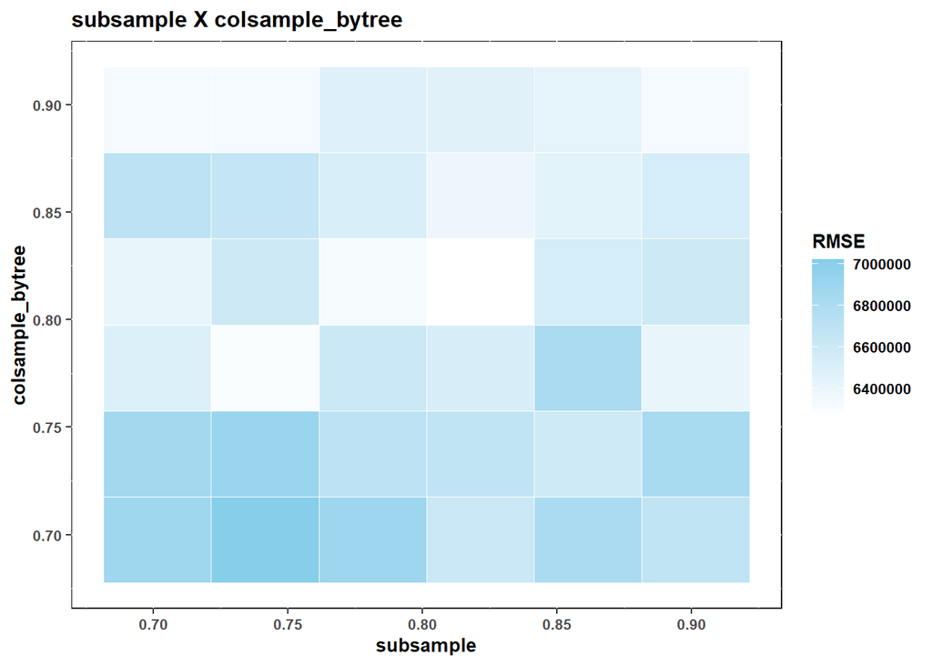

```r
ggplot(sub_col_grid) +
  geom_tile(aes(subsample, colsample_bytree, fill = RMSE), color = 'white') +
  labs(x = "subsample", y = "colsample_bytree", title = "subsample X colsample_bytree") +
  scale_fill_gradient("RMSE", low = "white", high = "skyblue") +
  theme(panel.background = element_rect(fill = "white" , color = "black"),
        text = element_text(face = "bold", size = 10))
```

#### 변수 비율이 높은 것이 rmse가 낮아 보이고, 샘플 비율은 플롯에서 유의미한 영향이 보이지는 않는다. 하지만 rmse가 가장 낮은 조합을 보면 둘 다 80% 이상으로 매 iteration에서 변수와 샘플 선택 비율이 높다. train 데이터 자체가 변수와 샘플 개수가 많지 않으므로 선택 비율이 낮으면 모델 성능이 떨어질 가능성이 있다고 추측할 수 있다.

```r
rm(xgb_mod_3, xgb_pred_3)
```

## 2-2-5

```r
eta_n_grid = expand.grid(eta = seq(tune_xgb$eta[9] - 0.05, tune_xgb$eta[9] + 0.05, 0.02),
                         nrounds = c(500, 600, 700), RMSE = NA)


pb <- progress_bar$new(total = 90)
for (i in 1:18){
  print(paste0('eta ', eta_n_grid[i,'eta']))
  print(paste0('nrounds ', eta_n_grid[i,'nrounds']))
  params = list(objective = 'reg:linear',
                max_depth = 6,
                min_child_weight = 3,
                subsample = sub_col_grid$subsample[22],
                colsample_bytree = sub_col_grid$colsample_bytree[22],
                eta = eta_n_grid$eta[i]
  )
  fold_RMSE = NULL
  for (k in 1:5){
    print(paste0(k, ' -FOLD'))
    index <- cv_xgb[[k]]
    train_x<- train_d[-index,]
    val_x <- train_d[index,]
    train_xgb = xgb.DMatrix(as.matrix(train_x %>% select(-AMT)), label = train_x$AMT)
    vali_xgb = xgb.DMatrix(as.matrix(val_x %>% select(-AMT)), label = val_x$AMT)
    watchlist = list(train = train_xgb, test = vali_xgb)

    set.seed(1234)
    xgb_mod_4 = xgb.train(params = params,
                          data = train_xgb,
                          watchlist = watchlist, nrounds = eta_n_grid$nrounds[i],
                          verbose = 0,
                          early_stopping_rounds = 0.05*eta_n_grid$nrounds[i]
    )
    xgb_pred_4 <- predict(xgb_mod_4, newdata = vali_xgb)
    RMSE <- RMSE(xgb_pred_4,val_x$AMT)
    fold_RMSE = c(fold_RMSE, RMSE)

    pb$tick()
    Sys.sleep(0.01)
  }
  mean_RMSE = mean(fold_RMSE)
  eta_n_grid[i,'RMSE'] <- mean_RMSE
}
```

```
## [1] "eta 0.177848057139199"
## [1] "nrounds 500"
## [1] "1 -FOLD"
## [1] "2 -FOLD"
## [1] "3 -FOLD"
## [1] "4 -FOLD"
## [1] "5 -FOLD"
## [1] "eta 0.197848057139199"
## [1] "nrounds 500"
## [1] "1 -FOLD"
## [1] "2 -FOLD"
## [1] "3 -FOLD"
## [1] "4 -FOLD"
## [1] "5 -FOLD"
## [1] "eta 0.217848057139199"
```

[output cut: 111 more lines]

## 2-2-6

```r
eta_n_grid[which(eta_n_grid$RMSE == min(eta_n_grid$RMSE)), ]
```

```
##          eta nrounds    RMSE
## 1  0.1778481     500 6135582
## 7  0.1778481     600 6135582
## 13 0.1778481     700 6135582
```

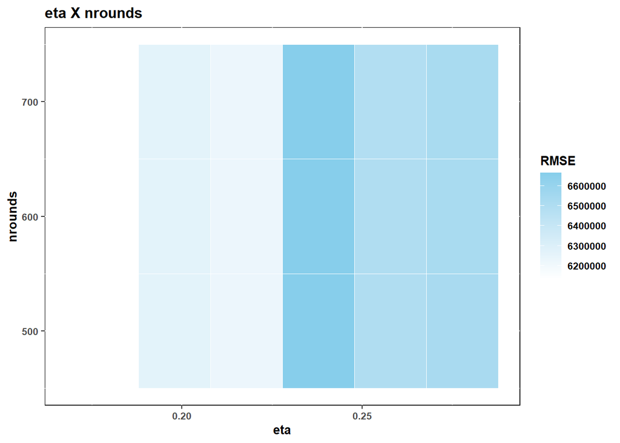

```r
ggplot(eta_n_grid) +
  geom_tile(aes(eta, nrounds, fill = RMSE), color = 'white') +
  labs(x = "eta", y = "nrounds", title = "eta X nrounds") +
  scale_fill_gradient("RMSE", low = "white", high = "skyblue") +
  theme(panel.background = element_rect(fill = "white" , color = "black"),
        text = element_text(face = "bold", size = 10))
```

# 3-1

```r
params = list(objective = 'reg:linear',
              max_depth = 6,
              min_child_weight = 3,
              subsample = sub_col_grid$subsample[22],
              colsample_bytree = sub_col_grid$colsample_bytree[22],
              eta = eta_n_grid$eta[13]
              )
watchlist = list(train = xgb_tr, test = xgb_te)

set.seed(1234)
xgb_mod_5 = xgb.train(params = params,
                      data = xgb_tr,
                      watchlist = watchlist, nrounds = eta_n_grid$nrounds[13],
                      verbose = 0,
                      early_stopping_rounds = 0.05*eta_n_grid$nrounds[13]
                      )
xgb_pred_5 <- predict(xgb_mod_5, xgb_te)
RMSE_xgb = RMSE(xgb_pred_5,test_d$AMT)
```

```r
train_d2 = dummy.data.frame(train %>% select(-YEAR))
test_d2 = dummy.data.frame(test %>% select(-YEAR))


xgb_tr2 = xgb.DMatrix(as.matrix(train_d2 %>% select(-AMT)), label = train_d2$AMT)
xgb_te2 = xgb.DMatrix(as.matrix(test_d2 %>% select(-AMT)), label = test_d2$AMT)

watchlist = list(train = xgb_tr2, test = xgb_te2)

set.seed(1234)
xgb_mod_6 = xgb.train(params = params,
                      data = xgb_tr2,
                      watchlist = watchlist, nrounds = eta_n_grid$nrounds[13],
                      verbose = 0,
                      early_stopping_rounds = 0.05*eta_n_grid$nrounds[13]
)
xgb_pred_6 <- predict(xgb_mod_6, xgb_te2)
RMSE_xgb_2 = RMSE(xgb_pred_6,test_d2$AMT)
```

#### 어차피 test에는 year 변수 level이 하나이므로 삭제도 한 번 해봤다. 삭제 한 게 더 좋게 나옴!

```r
set.seed(1234)
rf_mod_3 <- randomForest(AMT~., train, mtry = 6, ntree = 100)
rf_pred_3 <- predict(rf_mod_3, select(test_rf, -AMT))
RMSE_rf = RMSE(rf_pred_3, test_rf$AMT)



rng_mod_3 <- ranger(AMT~., train, mtry = 6, num.trees = 300, seed = 1234)
rng_pred_3 <- predict(rng_mod_3, select(test_rf, -AMT), seed = 1234)
RMSE_rng = RMSE(rng_pred_3$predictions, test_rf$AMT)
```

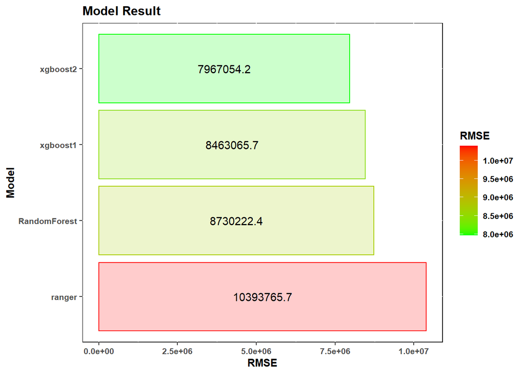

```r
result = data.frame(Model = c('RandomForest', 'ranger', 'xgboost1', 'xgboost2'), RMSE = c(RMSE_rf, RMSE_rng, RMSE_xgb, RMSE_xgb_2) %>% round(1) )

ggplot(result, aes(x = reorder(Model, - RMSE), y = RMSE)) +
  geom_col(aes(color = RMSE, fill = RMSE), alpha = 0.2) +
  coord_flip()+
  labs(x = "Model", y = "RMSE", title = "Model Result") +
  geom_text(aes(label = RMSE), position = position_stack(0.5)) +
  scale_fill_gradient("RMSE", low = "green", high = "red") +
  scale_color_gradient(guide = "none", low = "green", high = "red") +
  theme(panel.background = element_rect(fill = "white", color = "black"),
        text = element_text(face = "bold", size = 10))
```

#### year을 삭제한 xgboost, 범주 레벨을 맞춰준 xgboost, RandomForest, ranger 순으로 좋게 나왔다.